# Proyecto 4 - Clustering

Para esta proyecto vamos a implementar algunos algoritmos de clustering en una porción de un conjunto de datos sobre casos de crimen en Cambridge.

```python
import pandas            as pd
import numpy             as np
import matplotlib.pyplot as plt

from sklearn.cluster          import DBSCAN
from sklearn.decomposition    import PCA
from sklearn.model_selection  import GridSearchCV
from sklearn.svm              import SVC
from sklearn                  import preprocessing
from matplotlib               import colors
from sklearn.cluster          import KMeans
from sklearn.datasets         import make_blobs

from numpy                    import unique
from numpy                    import where
from matplotlib               import pyplot
from sklearn.datasets         import make_classification
from sklearn.cluster          import AgglomerativeClustering
from sklearn.metrics          import silhouette_score
```

Para empezar vamos a trabajar solo con las columnas *Crime, Reporting Area y Neighbor-hood*. Entonces eliminaremos las demás.

```python
# Cargar el archivo CSV
df = pd.read_csv("CrimenCambridge.csv")

# Seleccionar las columnas requeridas
df = df[['Crime', 'Reporting Area', 'Neighborhood']]

df.head()
```

|  | Crime | Reporting Area | Neighborhood |
| --- | --- | --- | --- |
| 0 | Simple Assault | 504.0 | Cambridgeport |
| 1 | Simple Assault | 610.0 | Mid-Cambridge |
| 2 | Aggravated Assault | 708.0 | Riverside |
| 3 | Simple Assault | 105.0 | East Cambridge |
| 4 | Disorderly | 708.0 | Riverside |

Convertiremos a Dummies las variables categóricas y tomamos una muestra aleatoria de 5000 registros.

```python
# Tomar una muestra aleatoria de 5000 registros
X = df.sample(n=5000, random_state=69)
X.head()

# Convertir variables categóricas a dummies
X2 = pd.get_dummies(X, columns = ['Crime', 'Neighborhood'])
X2
```

|  | Reporting Area | Crime_Accident | Crime_Admin Error | Crime_Aggravated Assault | Crime_Annoying & Accosting | Crime_Arson | Crime_Auto Theft | Crime_Commercial Break | Crime_Commercial Robbery | Crime_Counterfeiting | ... | Neighborhood_East Cambridge | Neighborhood_Highlands | Neighborhood_Inman/Harrington | Neighborhood_MIT | Neighborhood_Mid-Cambridge | Neighborhood_North Cambridge | Neighborhood_Peabody | Neighborhood_Riverside | Neighborhood_Strawberry Hill | Neighborhood_West Cambridge |
| --- | --- | --- | --- | --- | --- | --- | --- | --- | --- | --- | --- | --- | --- | --- | --- | --- | --- | --- | --- | --- | --- |
| 26127 | 305.0 | 0 | 0 | 0 | 0 | 0 | 0 | 0 | 0 | 0 | ... | 0 | 0 | 1 | 0 | 0 | 0 | 0 | 0 | 0 | 0 |
| 512 | 605.0 | 0 | 0 | 0 | 0 | 0 | 0 | 0 | 0 | 0 | ... | 0 | 0 | 0 | 0 | 1 | 0 | 0 | 0 | 0 | 0 |
| 36938 | 302.0 | 0 | 0 | 0 | 0 | 0 | 0 | 0 | 0 | 0 | ... | 0 | 0 | 1 | 0 | 0 | 0 | 0 | 0 | 0 | 0 |
| 11236 | 107.0 | 0 | 0 | 0 | 0 | 0 | 0 | 0 | 0 | 0 | ... | 1 | 0 | 0 | 0 | 0 | 0 | 0 | 0 | 0 | 0 |
| 16540 | 504.0 | 0 | 0 | 0 | 0 | 0 | 0 | 0 | 0 | 0 | ... | 0 | 0 | 0 | 0 | 0 | 0 | 0 | 0 | 0 | 0 |
| ... | ... | ... | ... | ... | ... | ... | ... | ... | ... | ... | ... | ... | ... | ... | ... | ... | ... | ... | ... | ... | ... |
| 2363 | 202.0 | 0 | 0 | 0 | 0 | 0 | 0 | 0 | 0 | 0 | ... | 0 | 0 | 0 | 1 | 0 | 0 | 0 | 0 | 0 | 0 |
| 1313 | 603.0 | 0 | 0 | 0 | 0 | 0 | 0 | 0 | 0 | 0 | ... | 0 | 0 | 0 | 0 | 1 | 0 | 0 | 0 | 0 | 0 |
| 22224 | 804.0 | 0 | 0 | 0 | 0 | 0 | 0 | 0 | 0 | 0 | ... | 0 | 0 | 0 | 0 | 0 | 0 | 0 | 0 | 0 | 0 |
| 13209 | 708.0 | 0 | 0 | 0 | 0 | 0 | 0 | 0 | 0 | 0 | ... | 0 | 0 | 0 | 0 | 0 | 0 | 0 | 1 | 0 | 0 |
| 11532 | 102.0 | 0 | 0 | 0 | 0 | 0 | 0 | 0 | 0 | 0 | ... | 1 | 0 | 0 | 0 | 0 | 0 | 0 | 0 | 0 | 0 |

5000 rows × 67 columns

Ahora, utilizamos Análisis de Componentes Principales (PCA) para reducir el conjunto de datos a uno de dimensión 2.

```python
# Crear una instancia de PCA con 2 componentes
pca = PCA(n_components=2)

X_train_pca = pca.fit_transform(X2)

# Obtener las coordenadas de los dos componentes principales
train_pc1_coords = X_train_pca[:, 0]
train_pc2_coords = X_train_pca[:, 1]

# Centrar y escalar los datos después de la reducción de dimensión
pca_train_scaled = preprocessing.scale(np.column_stack((train_pc1_coords, train_pc2_coords)))
XPCA = np.column_stack([train_pc1_coords, train_pc2_coords])
```

Luego hacemos un plot del conjunto de datos 2-dimensional.

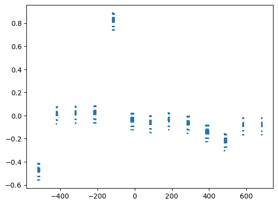

```python
plt.scatter(XPCA[:,0], XPCA[:,1], s = 0.8)
```

Podemos observar 13 grupos de datos.

Realizamos una función que nos permita hacer una visualización, en la que se distingan colores para los diferentes clusters establecidos por el algoritmo.

```python
import matplotlib.pyplot as plt

def scatter_plot(x, y, labels):
    """
    Create a scatter plot of points in two dimensions and color them according to a vector of numeric labels.

    Arguments:
    - x: List of x coordinates of the points.
    - y: List of y coordinates of the points.
    - labels: List of numeric labels for each point.
    """
    # Create the scatter plot with the "inferno" colormap
    plt.scatter(x, y, c=labels, cmap='inferno', s=8)

    # Add a colorbar to display the color mapping
    plt.colorbar()

    # Show the plot
    plt.show()
```

Implementamos el método DBSCAN de SKLearn.

```
Número de etiquetas encontradas con DBSCAN [ 0  1  2  3  4  5  6  7  8  9 10 11 12],
 es decir 13 clusters.
```

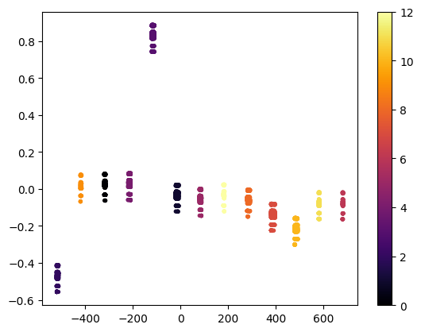

```python
clustering = DBSCAN(eps=2, min_samples=5).fit(XPCA)
labelsDB = clustering.labels_

print(f"Número de etiquetas encontradas con DBSCAN {np.unique(labelsDB)},\
        \n es decir {len(np.unique(labelsDB))} clusters.")

scatter_plot(XPCA[:,0], XPCA[:,1], labelsDB)
```

*¿Qué ocurre si damos a épsilon un valor menor que 1? ¿Por qué? ¿Qué parámetros logran una buena agrupación de los datos?*

Si le damos un valor a épsilon menor que 1 no agrupa bien los datos.

Para que ocurra una buena agrupación, necesitamos poner de parámetros `eps` $\geq$ 2. Esto podría explicarse así:

Cuando se establece `eps` con un valor pequeño, se restringe el tamaño del vecindario, lo que dificulta que los puntos se conecten y formen regiones densas. Como resultado, muchos puntos pueden ser etiquetados como ruido o valores atípicos en lugar de asignarse a clusters.

En DBSCAN, el valor apropiado de `eps` depende de la densidad y distribución de los puntos de datos. Si `eps` es demasiado pequeño, es posible que los clusters no sean capaces de capturar la estructura subyacente de los datos. Por otro lado, si `eps` es demasiado grande, puede llevar a la fusión de clusters distintos o a la formación de un único cluster grande.

Con esto podemos explicar por qué no se logra identificar correctamente el grupo con un `eps`< 2, básicamente por que el parametro es tan pequeño que permite que se creen clusters dentro del cluster que buscamos identificar.

Ahora, implementamos el algoritmo de K-means de SKLearn. Vamos aumentando progresivamente el numero de clusters y computando la distorsión y el puntaje de silhouette:

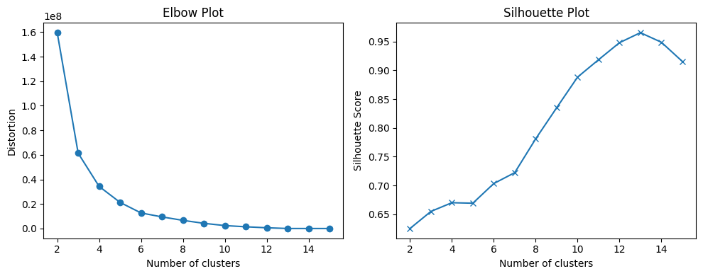

```python
def elbow_plot(data, max_clusters):
    """
    Build an elbow plot to determine the optimal number of clusters using the k-means algorithm.

    Arguments:
    - data: Input data array of shape (n_samples, n_features).
    - max_clusters: Maximum number of clusters to consider.

    Returns:
    - None (displays the elbow plot).
    """
    distortions = []
    silhouette = []

    for n_clusters in range(2, max_clusters+1):
        kmeans = KMeans(n_clusters=n_clusters)
        kmeans.fit(data)

        labels = kmeans.labels_
        silhouette_avg = silhouette_score(data, labels)

        silhouette.append(silhouette_avg)
        distortions.append(kmeans.inertia_)

    # Create subplots
    fig, (ax1, ax2) = plt.subplots(1, 2, figsize=(10, 4))

    # Plotting the elbow curve
    ax1.plot(range(2, max_clusters+1), distortions, marker='o')
    ax1.set_xlabel('Number of clusters')
    ax1.set_ylabel('Distortion')
    ax1.set_title('Elbow Plot')

    # Plotting the silhouette curve
    ax2.plot(range(2, max_clusters+1), silhouette, marker='x')
    ax2.set_xlabel('Number of clusters')
    ax2.set_ylabel('Silhouette Score')
    ax2.set_title('Silhouette Plot')

    # Adjust spacing between subplots
    plt.tight_layout()

    # Display the plot
    plt.show()

# Example usage
elbow_plot(XPCA, max_clusters=15)
```

La mejor dist está entre 3 y 4 clusters *(según la distorsión y el método del codo)* pero note que esto no contrasta con lo que sabemos *(son 13 grupos)*, sin embargo cuando nos guiamos por la métrica de la silueta vemos que la mejor elección es 13 clusters.

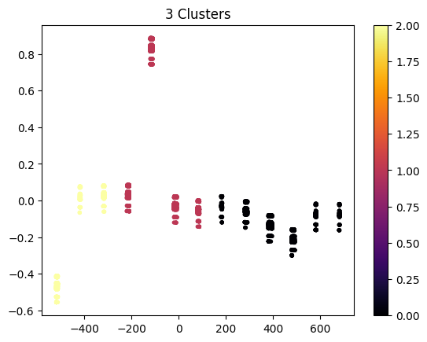

```python
kmeans = KMeans(n_clusters=3)
kmeans.fit(XPCA)

plt.title("3 Clusters")
scatter_plot(XPCA[:,0], XPCA[:,1], kmeans.labels_)
```

Con 4 Clusters vemos que el plot no es mucho mejor realmente, el algoritmo sigue haciendo un mal trabajo en encontrar el patrón de estos datos.

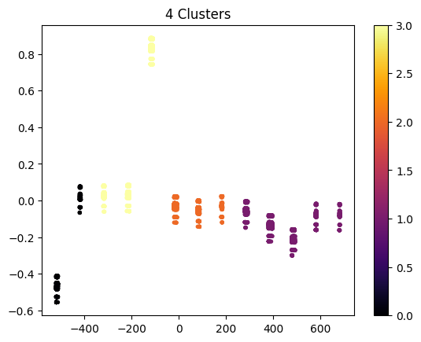

```python
kmeans = KMeans(n_clusters=4)
kmeans.fit(XPCA)

plt.title("4 Clusters")
scatter_plot(XPCA[:,0], XPCA[:,1], kmeans.labels_)
```

Si usamos lo que sabemos desde antes y nos confirma el método de la silueta, es decir que hay 13 categorías, podemos ver que el algoritmo lo hace adecuadamente:

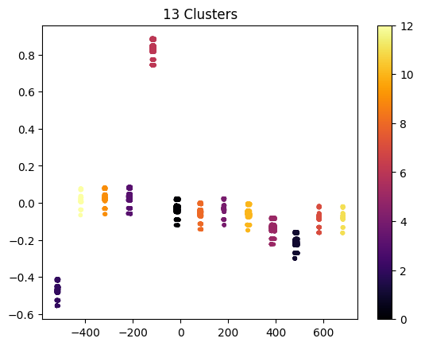

```python
kmeans = KMeans(n_clusters=13)
kmeans.fit(XPCA)

plt.title("13 Clusters")
scatter_plot(XPCA[:,0], XPCA[:,1], kmeans.labels_)
```

Ahora, implementamos el Algoritmo de agrupamiento de Jerarquía Aglomerativa que proporciona SKlearn, y hacemos una visualización de como progresa el puntaje de silueta conforme el número de nodos varía:

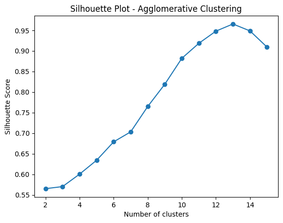

```python
def silhouette_plot_agglomerative(data, max_clusters):
    """
    Build an silhouette plot to determine the optimal number of clusters
    using the AgglomerativeClustering algorithm.

    Arguments:
    - data: Input data array of shape (n_samples, n_features).
    - max_clusters: Maximum number of clusters to consider.

    Returns:
    - None (displays the silhouette plot).
    """
    silhouette_scores = []

    for n_clusters in range(2, max_clusters + 1):
        clustering = AgglomerativeClustering(n_clusters=n_clusters)
        labels = clustering.fit_predict(data)

        silhouette_avg = silhouette_score(data, labels)
        silhouette_scores.append(silhouette_avg)

    # Plotting the elbow curve
    plt.plot(range(2, max_clusters + 1), silhouette_scores, marker='o')
    plt.xlabel('Number of clusters')
    plt.ylabel('Silhouette Score')
    plt.title('Silhouette Plot - Agglomerative Clustering')
    plt.show()

# Example usage
silhouette_plot_agglomerative(XPCA, max_clusters=15)
```

Para determinar el número óptimo de clusters utilizando AgglomerativeClustering, vamos a utilizar el método de la "silueta" (silhouette). La cúal es una medida de cuán bien cada muestra se ajusta a su propio cluster en comparación con otros clusters. Un valor alto de silueta indica una buena separación de los clusters.

Podemos observar en la gráfica que en este caso el número óptimo de cluster a utilizar es de 13.

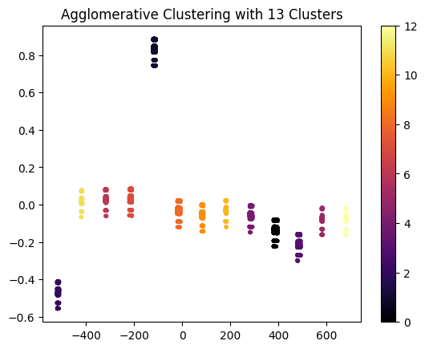

```python
agglomerative = AgglomerativeClustering(n_clusters = 13).fit(XPCA)
agglomerative_labels = agglomerative.labels_


plt.title("Agglomerative Clustering with 13 Clusters")
scatter_plot(train_pc1_coords, train_pc2_coords, agglomerative_labels)
```

Y podemos observar que el algoritmo lo hizo bien.

Finalmente, extraemos los índices de los registros contenidos de alguno de los clusters. Y vamos a ver si estos corresponden con los mismos índices en el dataset al que se le aplicó PCA. *¿Qué tienen en común los datos de dicho cluster?*

```python
X['labels'] = agglomerative_labels
X['Crime']  = X['Crime'].astype('category')
X['Neighborhood'] = X['Neighborhood'].astype('category')
X['Reporting Area']  = X['Reporting Area'].astype('category')
X
```

|  | Crime | Reporting Area | Neighborhood | labels |
| --- | --- | --- | --- | --- |
| 26127 | Threats | 305.0 | Inman/Harrington | 6 |
| 512 | Larceny from MV | 605.0 | Mid-Cambridge | 8 |
| 36938 | Flim Flam | 302.0 | Inman/Harrington | 6 |
| 11236 | Mal. Dest. Property | 107.0 | East Cambridge | 2 |
| 16540 | OUI | 504.0 | Cambridgeport | 1 |
| ... | ... | ... | ... | ... |
| 2363 | Larceny from MV | 202.0 | MIT | 11 |
| 1313 | Hit and Run | 603.0 | Mid-Cambridge | 8 |
| 22224 | Housebreak | 804.0 | Agassiz | 10 |
| 13209 | Larceny of Services | 708.0 | Riverside | 9 |
| 11532 | Shoplifting | 102.0 | East Cambridge | 2 |

5000 rows × 4 columns

```python
X.groupby(['Neighborhood', 'labels']).describe()
```

| Neighborhood | labels | Crime count | Crime unique | Crime top | Crime freq | Reporting Area count | Reporting Area unique | Reporting Area top | Reporting Area freq |
| --- | --- | --- | --- | --- | --- | --- | --- | --- | --- |
| Agassiz | 10 | 127 | 29 | Hit and Run | 18 | 127.0 | 5.0 | 804.0 | 59.0 |
| Area 4 | 7 | 554 | 41 | Domestic Dispute | 52 | 554.0 | 10.0 | 411.0 | 133.0 |
| Cambridgeport | 1 | 683 | 47 | Larceny from MV | 66 | 683.0 | 10.0 | 501.0 | 193.0 |
| East Cambridge | 2 | 702 | 44 | Shoplifting | 110 | 702.0 | 8.0 | 102.0 | 226.0 |
| Highlands | 5 | 129 | 28 | Hit and Run | 26 | 129.0 | 4.0 | 1204.0 | 53.0 |
| Inman/Harrington | 6 | 373 | 41 | Domestic Dispute | 40 | 373.0 | 5.0 | 305.0 | 138.0 |
| MIT | 11 | 100 | 24 | Hit and Run | 18 | 100.0 | 5.0 | 201.0 | 38.0 |
| Mid-Cambridge | 8 | 468 | 37 | Hit and Run | 47 | 468.0 | 13.0 | 602.0 | 73.0 |
| North Cambridge | 3 | 513 | 42 | Hit and Run | 69 | 513.0 | 13.0 | 1101.0 | 106.0 |
| Peabody | 4 | 316 | 34 | Larceny from MV | 43 | 316.0 | 13.0 | 910.0 | 72.0 |
| Riverside | 9 | 470 | 43 | Larceny from MV | 37 | 470.0 | 8.0 | 708.0 | 119.0 |
| Strawberry Hill | 12 | 105 | 26 | Domestic Dispute | 21 | 105.0 | 4.0 | 1303.0 | 68.0 |
| West Cambridge | 0 | 460 | 41 | Larceny from MV | 49 | 460.0 | 16.0 | 1002.0 | 213.0 |

Podemos ver que cada cluster es un barrio, y que todos estos cluster tienen un comportamiento bien diferenciados algunos con una alta variedad de crímenes y tasa de criminalidad alta (en comparación con las demás, en otros casos con una tasa de criminalidad baja). Los crímenes más frecuentes entre todos los barrios son 'Hit and run' junto con 'Domestic dispute' y 'Larceny from MV'.

[figure not shown]

Created in Deepnote